🦠 **Reviews in the Post-Pandemic Era** 🦠

Sorted *Worst-Best:* All 123 Responses

**Likeliness to Recommend**

**Why did you choose this rating?**

**What could have improved your experience?**

**Professional training session**

**Facilitator**

**Date**

**Likert Plot (Blue = Agree, Black = Disagree)**

0

I gained nothing from this experience today.

We really didn't know how to log into the call. Information before the meeting was confusing. I also stated that I was confused during the course and the presenter completely ignored the comment and continued to push through the content in order to complete two sessions at once.

Guidebooks Diverse Learners Vocabulary, Day 2

Holli

Dec, 04 2020

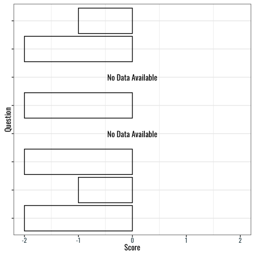

1

I chose this rating because I do not feel that EL can be taught correctly with distance learning. There is almost no support for using these materials that way. If a school pays this much money for this program, every part should be easily accessed by a student at home, and teachers should not have to put it into google or another program themselves. We should be the facilitators, not creating online resources.

There was difficulty with navigating between guides and other materials for me. I feel that the open source guides would be much easier to use if, when a direction is made, the page and book where the material is found was included.

EL Virtual Bootcamp

Vaishali

May, 19 2020

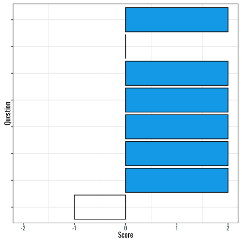

1

We were unable to really get into the info.

getting into materials more deeply

EL Virtual Bootcamp

Vaishali

May, 19 2020

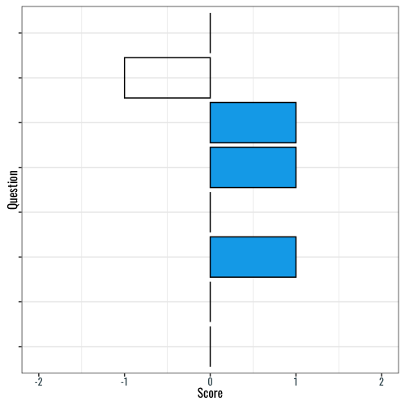

2

The learning is not what is expected based on the label.

Less talking and more doing

Guidebooks Diverse Learners Vocabulary, Day 2

Holli

Dec, 04 2020

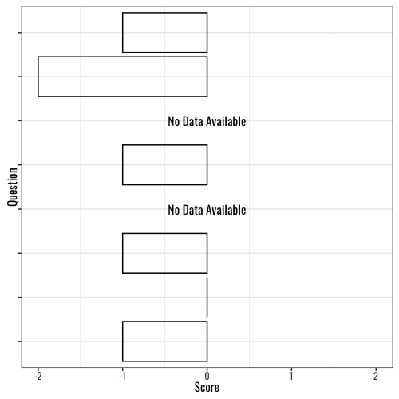

2

This was more about reflection on COVID and how HQI and shifts apply (which is important) but it is end of October and we need to use the time to move forward rather than 2 hours of reflection.

An agenda with objectives that we can see what learning targets are going to be met. Though good for building community, activities were too slow for two hours after a full work day. Need more purpose to the work.

Nebraska IM-PL Fellowship Virtual Series

Tara

Oct, 20 2020

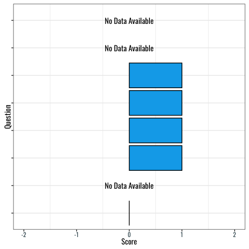

3

It did not meet the expectation of what I need which is to teach this curriculum effectively.

I wish we could have spent time on how the "teaching" part is going to look like (daily lessons, an assessment, etc.).

EL Virtual Bootcamp

Vaishali

May, 19 2020

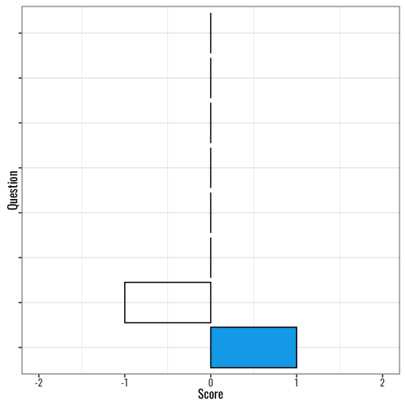

3

It was not easy to learn this virtually

face to face training

EL Virtual Bootcamp

Vaishali

May, 19 2020

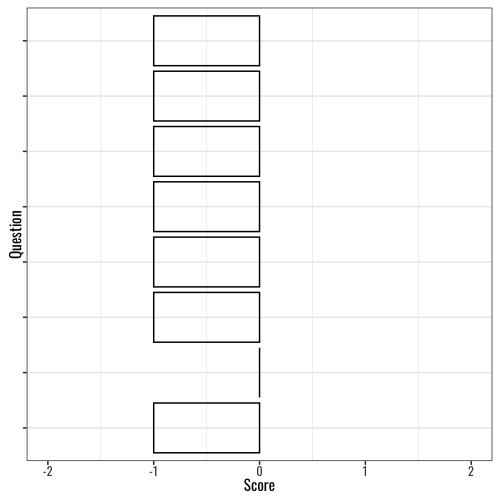

3

its was just hard to do alone...

more collaborations with our own school...

EL Virtual Bootcamp

Mandy

May, 19 2020

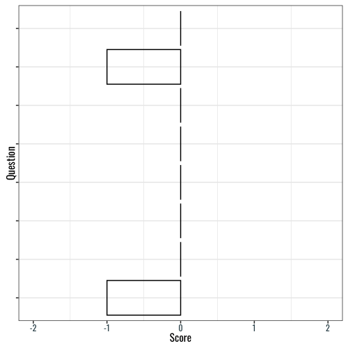

3

I already know these things. I'm certified so maybe that's why these are familiar habits

.

Guidebooks CM-6

Katie

May, 22 2020

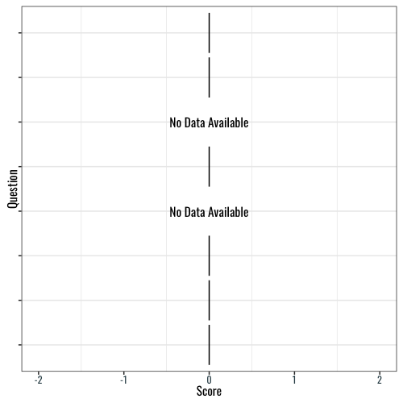

3

Repeat of previous work we've engaged.

We already did much of this work last year, and the focus on COVID seems to be already done/too late.

Nebraska IM-PL Fellowship Virtual Series

Tara

Oct, 20 2020

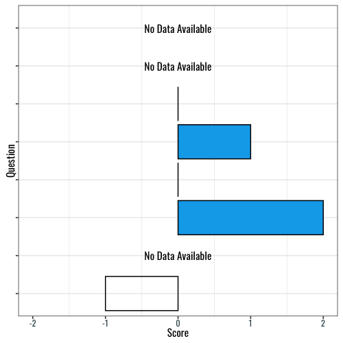

4

I don't feel like I got many strategies and tips to actually use in my room. This was mostly 'behind the scenes' stuff.

Seeing the curriculum in action

EL Virtual Bootcamp

Vaishali

May, 19 2020

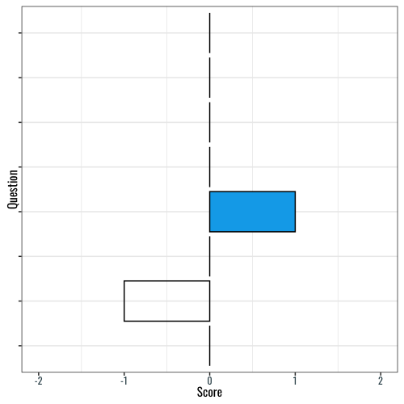

4

so much info and new way of teaching/learning that it was overwhelming

slowing down and more time to work within my grade level and talk with those teachers

EL Virtual Bootcamp

Mandy

May, 19 2020

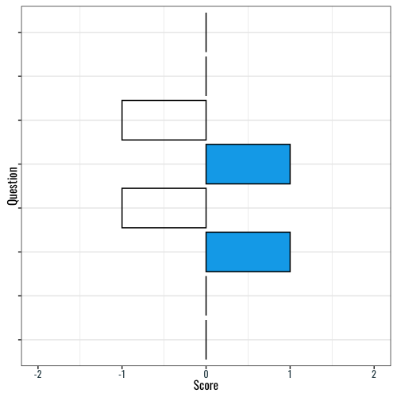

4

I didn't learn many new things.

The training was very spaced out; a more compact training might have helped the experience.

Guidebooks CM-6

Katie

May, 22 2020

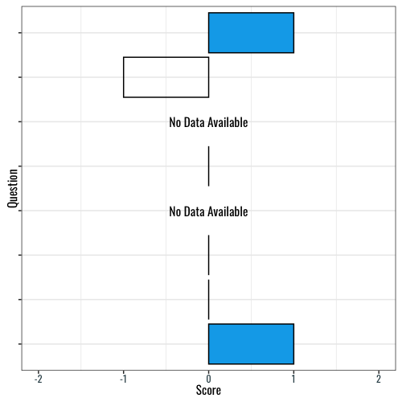

4

See previous responses.

The what to do and where to go directions were very confusing.

Guidebooks Diverse Learners BootCamp, Day 2

Holli

Aug, 17 2020

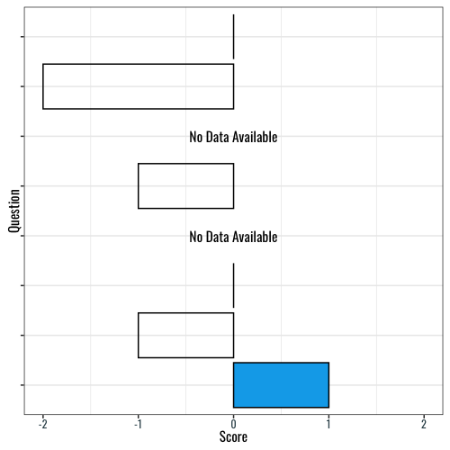

5

COVID

More information on the rest of the program, not just the modules. I understand how this is the module training, but maybe by giving an overview how it is all fitting together.

EL Virtual Bootcamp

Vaishali

May, 19 2020

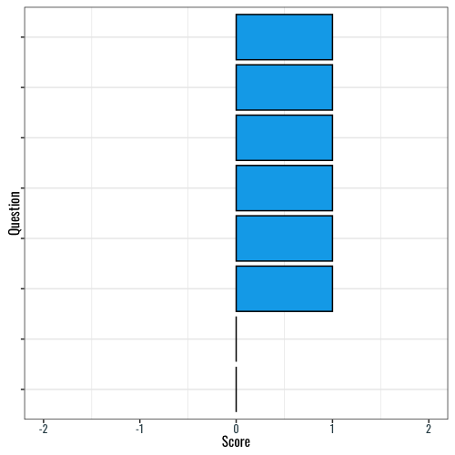

5

It was fine

The beginning seemed long before we could dig into materials.

EL Virtual Bootcamp

Vaishali

May, 19 2020

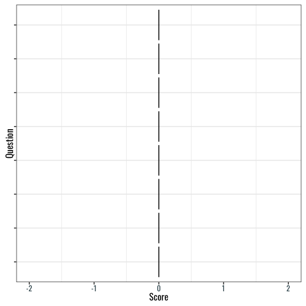

5

Parts of it were really strong but in person would be way better.

More handouts and more direct instructions for what we were supposed to do next or have with us, etc, It felt like I was flying blind most of the time.

EL Virtual Bootcamp

Vaishali

May, 19 2020

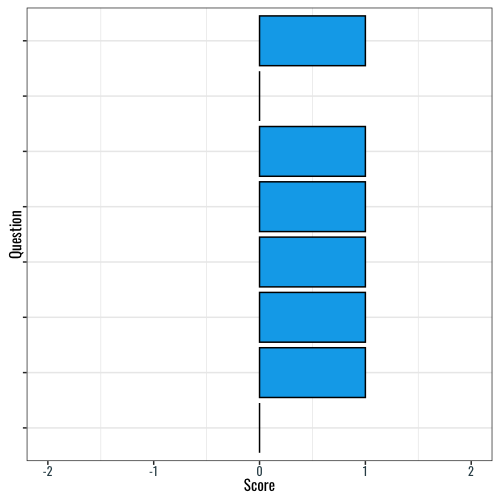

5

I don't feel secure in my role as a resource teacher to students and teachers using this curriculum.

I did not get my hands on the hard copy materials until Monday. It would have helped to have those in my hands. Also, I felt a lot of time was spent selling us on the merits of the program when our districts had already bought into it. It would have been beneficial to view a lesson being taught and to do some actual preparing or teaching of a lesson.

EL Virtual Bootcamp

Mandy

May, 19 2020

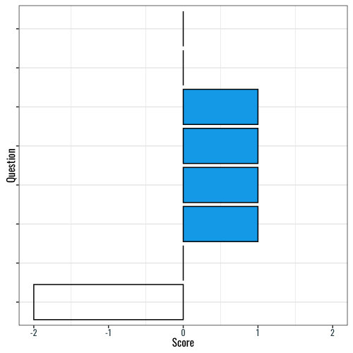

5

I felt they did the best they could with what they had, but in my opinion it could've been much deeper. I would've liked to have seen more in action... Yes, I know we all teach it a different way and it's not scripted, but it would be good for inspiration.

In person and more information that would be helpful during the teaching process.

EL Virtual Bootcamp

Mandy

May, 19 2020

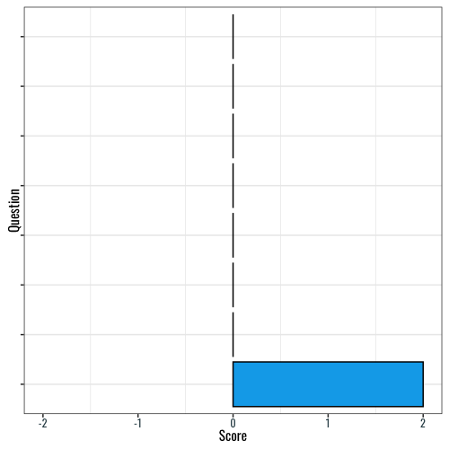

5

it is just hard to learn virtually

zoom calls

EL Virtual Bootcamp

Mandy

May, 19 2020

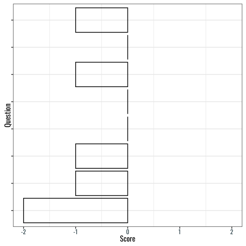

5

It was beneficial

Break up the information more

Guidebooks CM-6

Katie

May, 22 2020

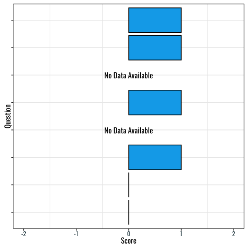

5

n/a

N/a

Guidebooks CM-6

Meredith

May, 22 2020

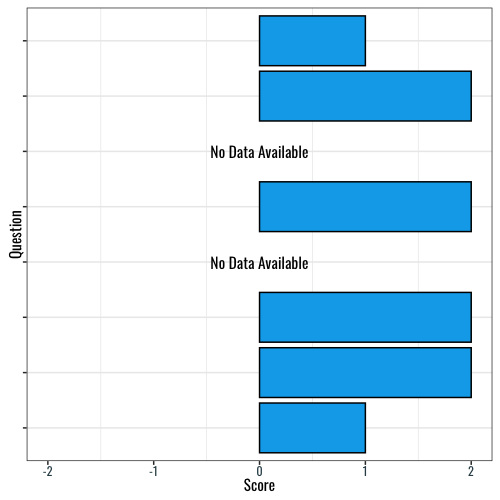

5

N/A

N/A

Guidebooks Diverse Learners BootCamp, Day 2

Holli

Aug, 28 2020

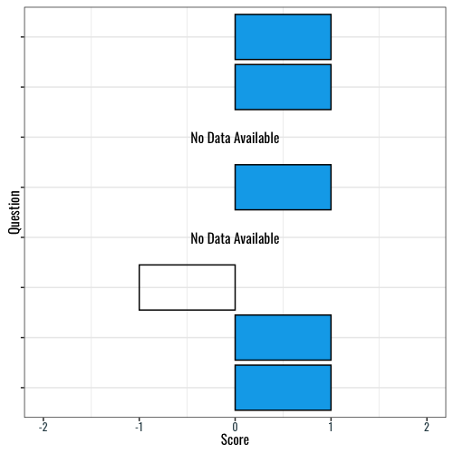

5

application

application

Guidebooks Diverse Learners BootCamp, Day 2

Holli

Dec, 04 2020

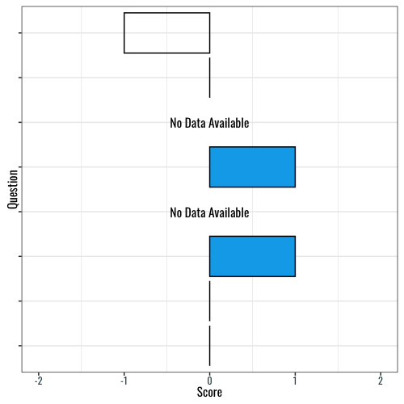

6

I participated in EL's profession development online courses concerning curriculum and teaching the material, so much of this seemed repetitive. However, because the material is brand new, it was still worth it for me as a review.

More chance to collaborate with same grade-level teachers. More opportunity to investigate the material with classroom teachers and formulate questions that would need answering.

EL Virtual Bootcamp

Vaishali

May, 19 2020

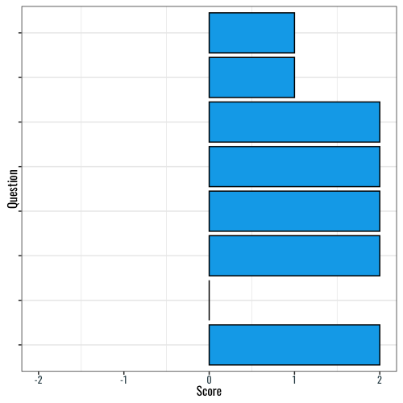

6

distance learning is difficult

better wifi

EL Virtual Bootcamp

Vaishali

May, 19 2020

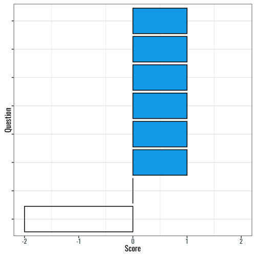

6